# Chapter 3 Section 1

Main [regresion results reference](https://www.statsmodels.org/stable/generated/statsmodels.regression.linear_model.RegressionResults.html).

```python
# !pip install seaborn==0.9.0
import numpy as np
import pandas as pd
import scipy
import scipy.stats
import matplotlib.pyplot as plt
import seaborn as sns
import statsmodels.api as sm
import statsmodels.formula.api as smf
sns.set()
import warnings
warnings.simplefilter('ignore',FutureWarning)
```

```python
advertising = pd.read_csv('http://www-bcf.usc.edu/~gareth/ISL/Advertising.csv')
advertising.drop(columns='Unnamed: 0', inplace=True)
```

```python
df = advertising.copy()
df_dependent = 'sales'
df_independent = ['TV','radio','newspaper']
df.columns
```

```
Index(['TV', 'radio', 'newspaper', 'sales'], dtype='object')
```

```python
lm = smf.ols('sales ~ TV', data=df).fit()
```

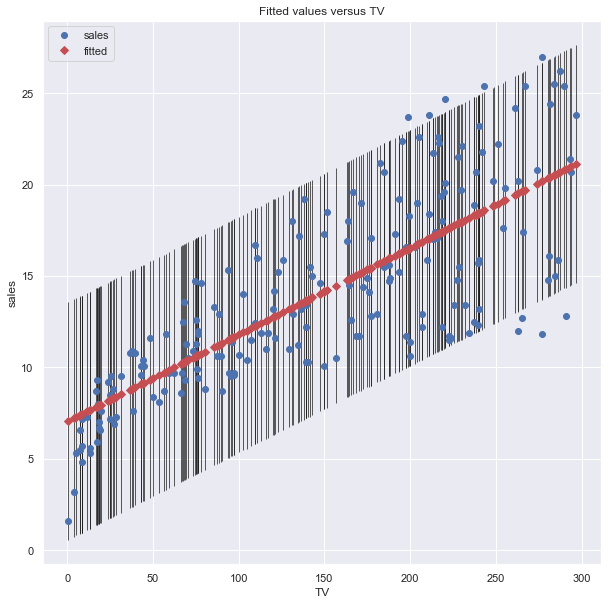

```python
_, ax = plt.subplots(figsize=(10,10))
sm.graphics.plot_fit(lm, exog_idx=1, ax=ax);
```

## Accessing results (important)

[Regression results](https://www.statsmodels.org/stable/generated/statsmodels.regression.linear_model.RegressionResults.html) [More attributes for OLS results](https://www.statsmodels.org/stable/regression.html) can be looked up.

Some important ones are:

```python
lm.params
```

```
Intercept    7.032594
TV           0.047537
dtype: float64
```

```python
rss = sum( np.square(df.sales - lm.params[0] - lm.params[1]*df.TV) )
rss
```

```
2102.5305831313503
```

In StatsModels, the way the RSS is actually used is its 'average': RSS divided by the number of degrees of freedom (DOF) left. This probably makes more sense after you study stats for another year or two. (I hope.)

- `df_resid` tells you the degrees of freedom of the residuals (it's just $n-p$).
- `mse_resid` is the mean square error of the residuals. The "mean" means divide by DOF of residuals.

We will see a use for `mse_resid` in Section 3.1.2

```python
lm.mse_resid * lm.df_resid
```

```
2102.5305831313517
```

For making decisions, you will probably read values off of the summary.

```python
lm.summary()
```

OLS Regression Results

| Dep. Variable: | sales | R-squared: | 0.612 |
| --- | --- | --- | --- |
| Model: | OLS | Adj. R-squared: | 0.610 |
| Method: | Least Squares | F-statistic: | 312.1 |
| Date: | Mon, 08 Oct 2018 | Prob (F-statistic): | 1.47e-42 |
| Time: | 13:08:54 | Log-Likelihood: | -519.05 |
| No. Observations: | 200 | AIC: | 1042. |
| Df Residuals: | 198 | BIC: | 1049. |
| Df Model: | 1 |  |  |
| Covariance Type: | nonrobust |  |  |

|  | coef | std err | t | P>\|t\| | [0.025 | 0.975] |
| --- | --- | --- | --- | --- | --- | --- |
| Intercept | 7.0326 | 0.458 | 15.360 | 0.000 | 6.130 | 7.935 |
| TV | 0.0475 | 0.003 | 17.668 | 0.000 | 0.042 | 0.053 |

| Omnibus: | 0.531 | Durbin-Watson: | 1.935 |
| --- | --- | --- | --- |
| Prob(Omnibus): | 0.767 | Jarque-Bera (JB): | 0.669 |
| Skew: | -0.089 | Prob(JB): | 0.716 |
| Kurtosis: | 2.779 | Cond. No. | 338. |

Warnings:  
[1] Standard Errors assume that the covariance matrix of the errors is correctly specified.

You should never retype values from the summary! If you need to do further analysis, find out the programmatic way to access the data, usually by looking it up in the [regression results page](https://www.statsmodels.org/stable/generated/statsmodels.regression.linear_model.RegressionResults.html).

Example: Which parameters have significances < 0.01?

```python
lm.pvalues < 0.01
```

```
Intercept    True
TV           True
dtype: bool
```

```python
lm.params
```

```
Intercept    7.032594
TV           0.047537
dtype: float64
```

### Figure 3.2 Reproduction

Reproducing Figure 3.2, left side, we want to make a contour plot showing how the RSS would change as we changed our estimates for $\beta_0$ and $\beta_1$. First we write a function that takes in the two parameters and produces the RSS for the model $sales =\beta_0 + \beta_1 * TV$ on the data set.

```python
def f_1(b0,b1):
    "Return RSS of prediction at (x,y)."
    return np.sum(np.square(df['sales'] - (b0 + b1*df['TV'])))
ff = np.vectorize(f_1)
```

Verify that our formula is finding the RSS...

```python
ff(7.032594, 0.047537)
```

```
array(2102.53058389)
```

```python
lm.mse_resid * lm.df_resid
```

```
2102.5305831313517
```

Good! Now we can make a contour plot. Remember we use `meshgrid` to get all of the ordered pairs of points out of an xrange and a yrange.

```python
(beta0, beta1) = lm.params
b0 = np.linspace(5,9,100)
b1 = np.linspace(0.025,0.07,100)
bb0, bb1 = np.meshgrid(b0,b1)
zz = ff(bb0,bb1)
```

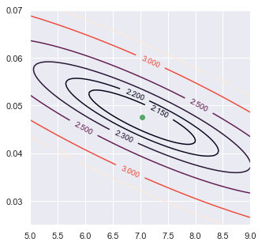

```python
fig,ax = plt.subplots(figsize=(5,5))
cplot = plt.contour(bb0, bb1, zz/1000, levels=[2.15,2.2,2.3,2.5,3,3.5])
plt.clabel(cplot, inline=1, fontsize=10)
ax.plot(beta0,beta1,'go')
plt.show();
```

My conclusion: this is why you do your own data analysis. Figure 3.2 (page 63) in the book appears to be a contour plot of RSS/1000 based on the labels drawn on the level curves. Except that the level curves are not circles in my plot and I do not think we are close enough to the picture in the book to explain the difference by scaling.

**Question**: Why does the contour 3.5 not appear on the graph? Matplotlib documentation is not very clear about the use of the top contour. Apparently it is not drawn, but still affects the colors of the drawn contour (try changing it from 3.5 to 6). **Dislike.**

### Figure 3.3 Reproduction

```python
samplesize = 50
xs = scipy.stats.expon.rvs(size=samplesize, loc=-2, scale=5)
xs = xs[ (-2<=xs) & (xs<=2) ]
noise = scipy.stats.norm.rvs(size=len(xs),scale=5)
```

```python
def f33(x): return 2+3*x
ys = 2+ 3*xs + noise
fig33df = pd.DataFrame({'x':xs, 'y': ys})
```

```python
fig33lm = smf.ols('y~x', data=fig33df).fit()
```

NOTE: if you switch the xs (exog) and ys (endog), OLS does not give an error until you ask for a summary.

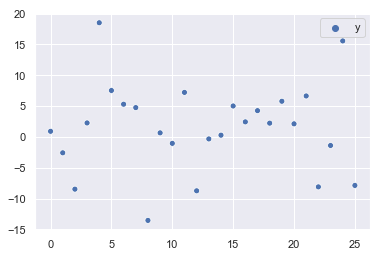

```python
ax = sns.scatterplot(data=fig33df);
```

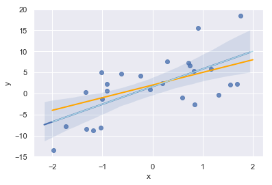

```python
_, ax = plt.subplots();
sns.regplot(x='x',y='y',data=fig33df,ax=ax);
ax.plot([-2,2],[f33(-2),f33(2)],color='orange', linewidth=2);
(b0,b1) = fig33lm.params
ax.plot([-2,2],[b0+b1*(-2),b0+b1*(2)], color='lightblue');
```

```python
def newfit(samplesize=50):
    xs = scipy.stats.expon.rvs(size=samplesize, loc=-2, scale=5)
    xs = xs[ (-2<=xs) & (xs<=2) ]
    noise = scipy.stats.norm.rvs(size=len(xs),scale=5)
    ys = 2+ 3*xs + noise
    fig33df = pd.DataFrame({'x':xs, 'y': ys})
    fig33lm = smf.ols('y~x', data=fig33df).fit()
    (b0,b1) = fig33lm.params
    return (b0,b1)
def qplot(ax, b0=None, b1=None, samplesize=50, color='blue'):
    if (b0 == None) ^ (b1 == None): raise RuntimeError('Must specify both b0 and b1')
    if b0 == None and b1== None: (b0,b1)=newfit(samplesize)
    ax.plot([-2,2],[b0+b1*(-2),b0+b1*(2)], color=color);
```

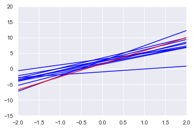

```python
_, ax = plt.subplots()
ax.set_xlim(-2,2)
ax.set_ylim(-15,20)
for _ in range(10):
    qplot(ax)
qplot(ax=ax,b0=b0,b1=b1,color='red')
```

## Section 3.1.2: Read before class!

This section is dense. You want to have seen it before you hear it. Answer the following reading questions.

- What is the population regression line?
- What is the difference between the population regression line and the least sqaures line?
- What does $\hat{\mu}$ mean?
- What is the standard error $SE(\hat{\mu})$?
- Can you prove the formula given for the variance of $\hat{\mu}$? Try it.
- What disclaimer appears footnote 2? What do you make of it?
- You do not have to try to prove the formulas in (3.8) - we will do that as part of our homework. If you were studying this book on your own, you would attempt to prove each formula as you read it.
- The text says that the assumption that errors are "uncorrelated and have common variance $\sigma^2$" is "clearly not true in Figure 3.1". What do the authors see in Figure 3.1 that makes this so "clear"? Explain.
- What characteristic of the independent variable observations ($x_i$) makes $SE(\hat{\beta}_1)$ small?
- What characteristic of the independent variable observations makes the standard error of $\hat{\beta}_0$ the same as the standard error of the estimate of the population mean ($\hat{\mu}$)?
- What is the definition of a confidence interval? (The assumption that you mean 95% confidence is standard in this stats usage.)
- What is the definition of a $t$-statistic for an estimate?
- What is a $p$-value? How does it relate to a large value for $|t|$?
- TODO: Make our own simulated data and analyze different runs. (Create our own graphs like Figure 3.3.)
- TODO: Demonstrate least squares is unbiased estimator.
- TODO: Discuss the footnote 3 about the approximations for the confidence interval in class. Also to mention: $\alpha = 1-\text{confidence}$.

```python
np.sqrt(lm.mse_resid)
```

```
3.258656368650463
```

Check that it is the same as the result from the book.

```python
rss = sum( np.square(df.sales - lm.params[0] - lm.params[1]*df.TV) )
np.sqrt(rss / (lm.nobs-2) )
```

```
3.258656368650462
```

There is a confidence interval function. It has an option for columns (`cols`) which appears broken to me. You just need to get the info you need out of the resulting Pandas data frame.

- Get the 99% confidence intervals for both.
- Find the 95% confidence interval for TV advertising as Pandas object.

```python
lm.conf_int(alpha=0.01) # 99% confidence
```

|  | 0 | 1 |
| --- | --- | --- |
| Intercept | 5.841796 | 8.223391 |
| TV | 0.040539 | 0.054535 |

```python
lm.conf_int() # 95% confidence is the default
```

|  | 0 | 1 |
| --- | --- | --- |
| Intercept | 6.129719 | 7.935468 |
| TV | 0.042231 | 0.052843 |

```python
lm.conf_int().loc['TV']
```

```
0    0.042231
1    0.052843
Name: TV, dtype: float64
```

## Section 3.1.3 Assessing Model Accuracy

Reading questions:

- What does RSE stand for?
- What does RSE tell you, roughly?
- In the case of a regression exactly finds the population regression line, will RSE be zero? Explain why or why not.
- In our discussion of the Bias-Variance decomposition a problem, which component relates to the RSE?
- Why is $R^2$ better than RSE for measuring error in general?
- Note: I think sometimes TSS-RSS is known as ESS, the explained sum of squares.
- How is the correlation Cor(X,Y) related to the covariance?
- How is $R^2$ related to correlation?
- TODO: Math to show that $R^2=r^2$?
- Not much to do in this section on a computer. This would be a good day to simulate data for Figure 3.3.

```python
lm.ess
```

```
3314.6181668686486
```

```python
lm.mse_resid
```

```
10.618841328946221
```

## Bug report - or at least crappy experience

```python
## FIXME: define lm2 if you want to keep this code here.
a = lm2.params
```

[output not shown]

```python
a
```

```python
a[1]
```

```python
a[[2,3]]
```

```python
cols = np.asarray([2,3])
a[cols]
```

```python
# ERRORS
#lm2.conf_int(cols=[2,3])
```